# tmpp6i2aawd

## 思想剧场：班级宪法制定大会

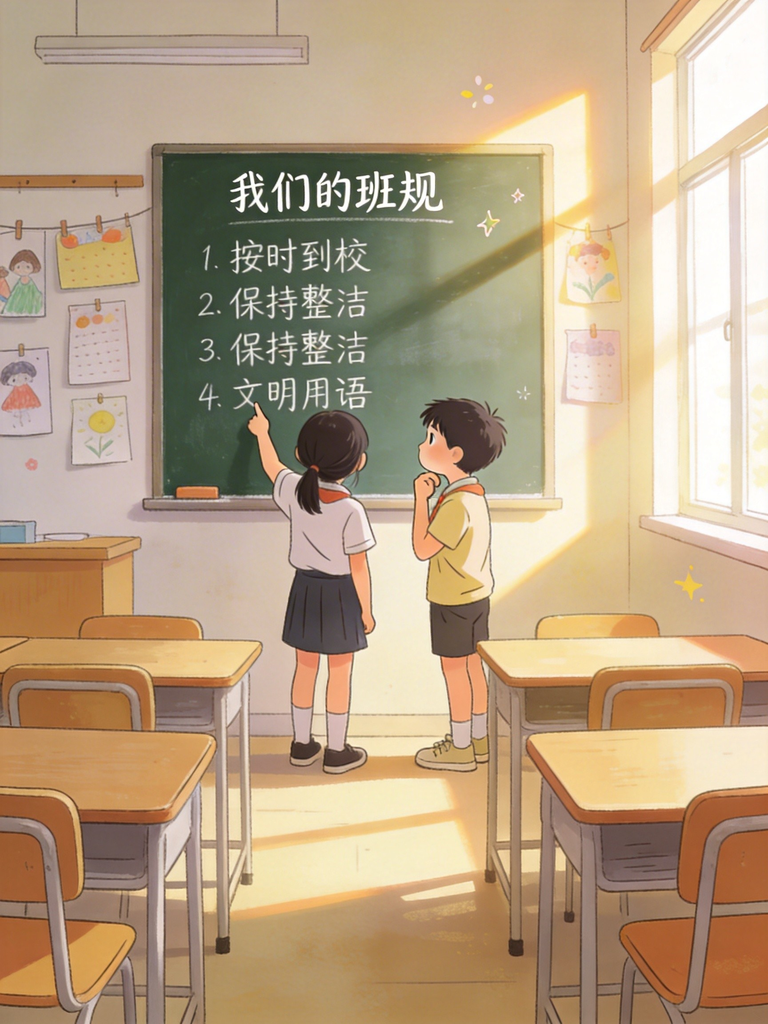

## 第一站：墨子的“兼爱”——无差别的爱心Wi-Fi🌟

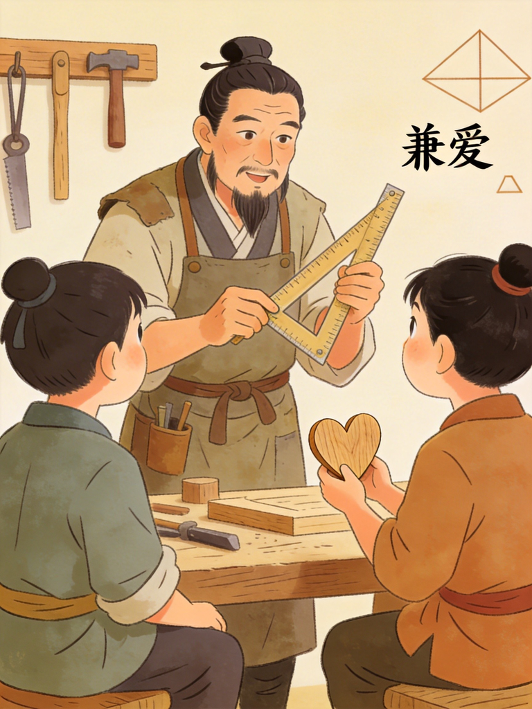

## 第二站：孟子的“仁政”——园丁式管理🌟

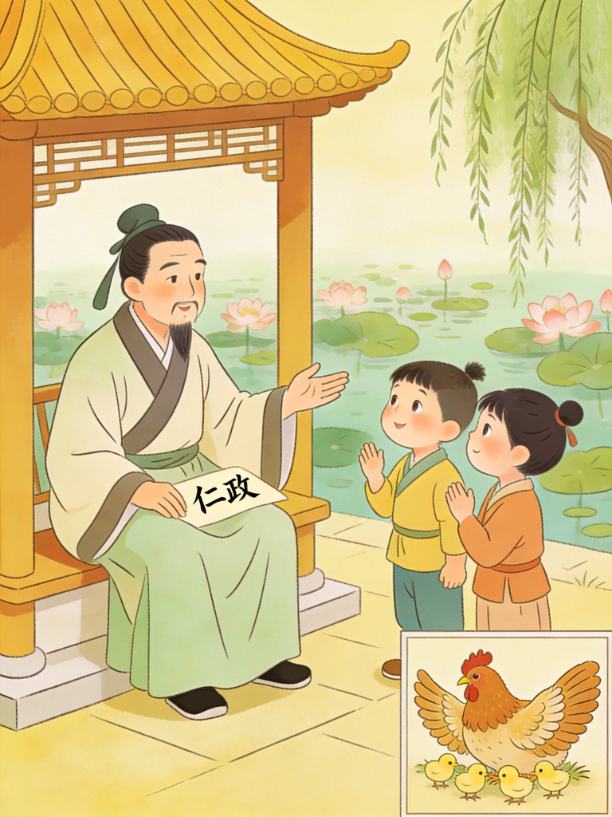

## 第三站：法家的“法治”——公平的游戏规则🌟

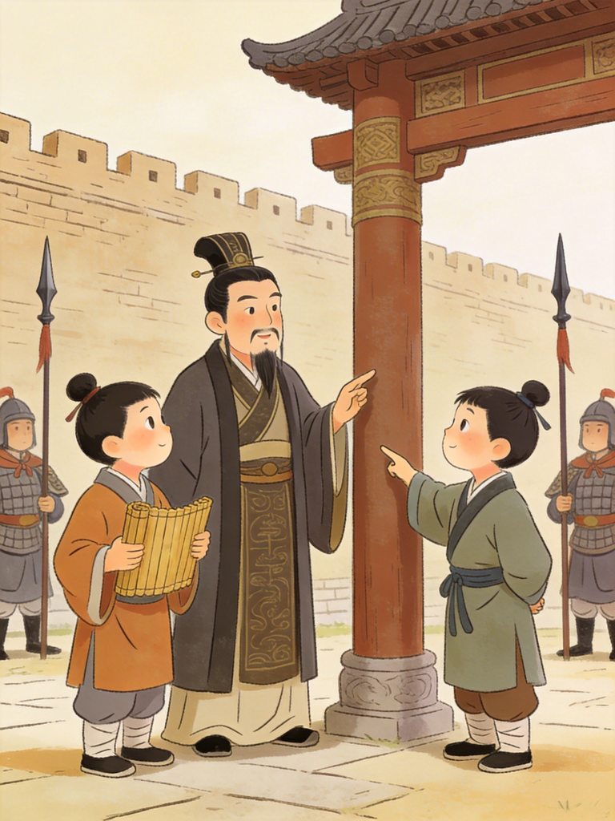

# 第五章 什么是“好”的规则？ **时间**：新学期第一次班会  
**地点**：五年级（3）班教室  
**人物**：小星（10岁，爱问“为什么”的女孩）、小宇（11岁，喜欢编程的男孩）、全班同学、三位古代立法顾问 （幕起） 教室黑板上写着醒目的标题： **“我们的班级宪法：什么样的规则才是‘好’规则？”** 班主任站在讲台前：“同学们，这学期我们要一起制定班级宪法。但首先，我们需要想清楚——到底什么样的规则，才算真正‘好’的规则？” **小星**举手：“我觉得应该公平！不能因为谁是班长就特殊对待。” **小宇**补充：“但也要能执行，不能定一堆谁都不遵守的空话。” **小明**站起来：“规则应该让我们变好，不只是管住我们！” **小红**反驳：“那也要尊重我们的自由啊！” **小宇**：（再次举手）我觉得规则还要有弹性！就像编程里的if-else语句，不同情况要有不同处理方式。 同学们争论不休时，教室后方三束光影亮起。三位古代智者以现代顾问的形象登场： - **墨子**（兼爱Wi-Fi设计师🌟），手持发光的信号发射器：“我的宪法方案叫‘无差别公平’——规则要像Wi-Fi信号，覆盖每一个人。” - **孟子**（仁政园丁🌟），捧着一盆正在生长的绿植：“我的方案叫‘成长型规则’——规则要像园丁的手，帮助每棵植物找到最适合的生长方式。” - **韩非子**（法治裁判员🌟），胸前挂着哨子，手持战术板：“我的方案叫‘可执行框架’——规则要像足球赛的边线，清晰、明确、能判罚。” **三人齐声**：我们是你们的**规则设计顾问团**！ **小星的即兴提问**：（走到台前）等一下！你们三位的主张听起来都很有道理，但好像又互相矛盾——我们该听谁的？ **墨子**：（信号器闪烁）这正是宪法制定的第一课——**好规则必须经过多重论证的考验**。 **小宇的笔记**：第一回合启动——公平、成长、执行，哪个才是好规则的核心？ — ### 古人说

**原文**： > “兼相爱，交相利。” > Jiān xiāng ài, jiāo xiāng lì. **字词解释**： - **兼相爱**：同时爱所有人，没有差别。 - **交相利**：互相带来利益，形成良性循环。 **趣味比喻**： 墨子的“兼爱”像**无差别的爱心Wi-Fi**——信号覆盖全班，不因为你是班长、学霸、或是新同学而强弱不同。 **生活案例**： > 班级图书角管理规则： > - **差等规则**：班长可以借5本，普通同学只能借1本。 > - **兼爱规则**：每人每次限借2本，对所有同学一视同仁。 > > 结果：差等规则导致不满，兼爱规则让更多同学愿意分享和遵守。

### 墨子的宪法原理：绝对公平论 墨子认为，所有社会问题的根源在于**爱有差等**： 1. **家庭偏爱** → 资源向亲人倾斜 2. **朋友小圈子** → 机会被少数人垄断  
3. **陌生人排斥** → 新同学、弱势者被忽视 **好规则的标准**：消除一切基于关系的特权，建立**人人平等**的行为框架。 **小星的辩论回合**： **小星**：墨老师，您的想法很理想，但现实吗？我对父母的感情，和对陌生人的感情，天然就是不同的啊！ **墨子**：（点头）你提了一个关键问题。请注意，“兼爱”不是说**感情**要完全一样，而是说**行为标准**要一样。 **小宇**追问：什么意思？能举个具体例子吗？ **墨子**：比如班级投票选“每月之星”，你不能因为A是你的好朋友就投他，而应该看谁**真正符合标准**（帮助他人、进步最大等）。你的**情感**可以更亲近好朋友，但**投票行为**必须公平。 **小星**：那资源分配呢？我只有一个苹果，给亲妹妹还是给陌生同学？ **墨子**：这正是考验！在**非紧急生存**情况下（比如班级活动奖品），应该按明确规则分配；在**紧急生存**情况下（比如只剩一口水），自然优先给亲人——但规则要事先明确定义“紧急情况”的标准。 **小宇**：（思考状）就像我们学校午餐的水果分配！有时候苹果不够，老师会把一个苹果切成两半给两个同学，这也是一种公平吗？ **墨子**：很好的例子！如果切苹果的规则是事先明确的（比如“不够时平分”），并且大家都同意，那么这就是墨子的“兼爱”公平——不因为谁跟老师关系好就得到更大的那一半。 **小星**追问：但要是有人不喜欢吃苹果，想换香蕉呢？规则能考虑到每个人的不同喜好吗？ **墨子**：问得好！规则不能完美满足每个人的偏好，但可以设计“偏好表达机制”——比如提前统计大家喜欢的水果，或者允许小范围交换。关键是要有透明的流程，而不是靠私下关系调整。 **孟子的插话**：（温和地）墨子，你这样会不会把人都变成“规则机器人”，忽略了情感的温暖？ **墨子**：恰恰相反！**明确的公平规则，恰恰能减少因偏爱产生的嫉妒、怨恨、冲突**——让大家的关系更纯粹、更温暖。 — ### 古人说

**原文**： > “老吾老，以及人之老；幼吾幼，以及人之幼。” > Lǎo wú lǎo, yǐjí rén zhī lǎo； yòu wú yòu, yǐjí rén zhī yòu. **字词解释**： - **老吾老**：尊敬自己的长辈。 - **以及人之老**：推及到尊敬别人的长辈。 - **幼吾幼**：爱护自己的孩子。 - **以及人之幼**：推及到爱护别人的孩子。 **儿童版核心**：从爱身边的人开始，慢慢把这份爱扩大到更多人。 **趣味比喻**： 孟子的“仁政”像**园丁式管理**——好园丁不会硬把花枝掰弯，而是提供阳光、水分、支架，让每朵花按自己的特点自然长好。 **生活案例**： > 两种作业检查规则对比： > > - **机械规则**：每天必须完成10页练习，没完成罚抄20遍。 > - **仁政规则**：根据学习进度分层作业，完成后提供“挑战题”选项；没完成的同学先了解原因，提供辅导计划。 > > 结果：机械规则制造焦虑和抄袭；仁政规则激发主动性和互助精神。

### 孟子的宪法原理：成长导向论 孟子认为，好规则不仅要公平，更要**促进人的道德成长**： 1. **养民**：保障基本需求（安全、温饱、教育） 2. **教民**：提供榜样、文化、价值观引导  
3. **用民**：让每个人发挥所长，贡献社会 **坏规则的标志**：让人变得更自私、更冷漠、更逃避责任。 **好规则的标志**：让人自愿做好事，内心感到充实和快乐。 **小宇的追问回合**： **小宇**：孟老师，您的“仁政”听起来很温暖，但会不会太“软”？如果有人就是故意不遵守，怎么办？ **孟子**：（微笑）问得好！“仁政”不是没有底线，而是**底线之上充满弹性**。比如： - **初犯**：了解原因，提醒规则精神 - **再犯**：明确后果，给予改正机会  
- **屡犯**：按明确规则处罚，但处罚后仍提供回归正轨的路径 **小星**质疑：这不还是惩罚吗？和韩非子的“法治”有什么区别？ **孟子**：区别在于**目的**！仁政的惩罚是为了**教育**，让人认识到错误，重新成长；单纯的法治惩罚可能只是为了**威慑**，让人因为害怕而服从。 **小宇**：（点头）我有点倾向于孟老师的观点。上次我数学作业没做完，老师没有直接罚我，而是问我是不是没听懂，还给我单独讲了半小时。后来我不仅补了作业，还主动多做了练习题。 **孟子**：（微笑）这就是“仁政”的效果！惩罚如果只是让人害怕，下次他会更隐蔽地违规；但如果让人内心认同规则、自愿遵守，那才是长久的改变。 **韩非子插话**：（冷静）孟子，你的理想很美好，但执行成本太高。每个违规都要了解原因、个性化处理——老师忙得过来吗？ **孟子**：这正是设计智慧所在——**大部分规则应该通过“氛围营造”和“榜样示范”来维护**，只有少数核心规则需要动用惩罚。就像好园丁，大部分时间是在浇水施肥，偶尔才需要修剪病枝。 — ### 古人说

**原文**： > “法不阿贵，绳不挠曲。” > Fǎ bù ē guì, shéng bù náo qū. **字词解释**： - **法不阿贵**：法律不偏袒权贵。 - **绳不挠曲**：就像墨线不迁就弯曲的木头，规则必须严格执行。 **趣味比喻**： 韩非子的“法治”像**足球场的边线**——没有边线，你哪里都能跑，但那不是足球；有了清晰的边线，你在规则内奔跑、传球、射门——这才是真正的竞技自由。 **生活案例**： > 班级手机管理规则： > > - **模糊规则**：“上课不要玩手机。”（什么叫“玩”？看时间算不算？） > - **法治规则**：“上课期间，手机必须设为静音并放入书包。紧急情况需使用，须先举手征得老师同意。” > > 结果：模糊规则引发争议（“我只是看了一下时间！”）；法治规则明确，易于执行和判断。

### 韩非子的宪法原理：执行效能论 韩非子认为，好规则必须满足**三个可执行条件**： 1. **势（权威）**：规则必须有明确的执行者和支持者（老师、家长、学校） 2. **法（明确）**：规则必须文字清晰，没有模糊空间 3. **术（方法）**：必须有具体的检查、判断、处罚流程 **坏规则的典型**：“大家要互相爱护”（怎么判断？谁执行？违反怎么办？） **好规则的典型**：“值日生每天检查卫生，不合格的小组次日重做并记录一次。”（谁、何时、查什么、不合格怎么办——全明确） **小星的质疑回合**： **小星**：韩老师，您的规则听起来很严格，但会不会扼杀我们的创造力？大家都变成“规则机器人”？ **韩非子**：（严肃）恰恰相反！**明确的规则，恰恰为创造力提供了安全的边界**。就像足球，有了边线、球门、犯规处罚，你才能放心地展示盘带、传球、射门的创意，不用担心对手直接把你推倒。 **小宇**追问：那规则太多怎么办？我们会不会被各种“不许”束缚？ **韩非子**：记住**最小必要原则**——只制定那些**非有不可**的规则。每定一条规则前，问三个问题： 1. 没有这条规则，会出现什么**具体**问题？ 2. 这条规则能**有效**解决这个问题吗？  
3. 执行这条规则的成本（时间、精力）值得吗？ **小星**：（皱眉）可是有时候问题很复杂，很难一下子想清楚到底需要什么规则。比如我们班最近在讨论“能不能带课外书到学校”，有的同学说可以丰富知识，有的说会分散注意力，大家吵了好几次也没定下来。 **韩非子**：这正是需要**试错机制**！可以先制定一个临时规则（比如“允许带，但只能在午休时间看”），试行两周，收集反馈，再调整。法治不是一成不变，而是**建立规则修订的明确流程**。 **墨子的对比**：韩非子，你的规则虽然明确，但会不会太“冷冰冰”？缺少人性的温暖？ **韩非子**：**规则的温暖，不在于条文本身，而在于执行时的公正和透明**。当每个人都相信规则会公平适用，不需要靠关系、讨好、眼泪来争取利益时——这才是最大的温暖。 — ## 想一想（互动升级版）

请拿出笔，在书上空白处写下你的真实想法——没有标准答案，只有你的探险笔记！

### 问题一：我的“规则偏好”探测器 | 情境 | 墨子型（绝对公平） | 孟子型（成长导向） | 韩非子型（执行效能） | 你的倾向 | |——|——————-|——————-|———————|———-| | **班级选举** | “每人一票，标准公开，禁止拉票” | “鼓励参选，提供演讲培训，重视进步过程” | “明确候选人资格、投票流程、结果公示时间” | □墨 □孟 □韩 | | **作业检查** | “统一标准，按时提交，迟交扣分” | “分层作业，个性化反馈，重视理解过程” | “明确提交方式、截止时间、迟交处罚细则” | □墨 □孟 □韩 | | **矛盾调解** | “按班规判定对错，同等处罚” | “了解双方感受，寻找共赢方案，促进关系修复” | “按投诉流程处理，记录存档，防止再次发生” | □墨 □孟 □韩 | **分析你的选择**： - 选**墨子多**：你可能特别重视公平，讨厌特权和不公 - 选**孟子多**：你可能更看重人的成长和关系的和谐  
- 选**韩非子多**：你可能注重效率和明确性，讨厌模糊和扯皮 ### 问题二：班级宪法设计挑战 假设你是班级宪法起草委员会主席，请为以下三个领域设计规则草案： | 领域 | 墨子版（公平优先） | 孟子版（成长优先） | 韩非子版（执行优先） | 你的综合版 | |——|——————-|——————-|———————|————| | **课堂发言** | “按学号顺序轮流，每人限时2分钟” | “鼓励主动发言，提供发言技巧指导，重视思考过程” | “举手发言，老师点名，记录发言次数确保均衡” | __________ | | **小组合作** | “角色轮流担任（组长、记录员、汇报人），任务平均分配” | “根据成员特长分工，提供合作技巧培训，重视团队成长” | “明确分工、截止时间、成果评价标准” | __________ | | **奖惩制度** | “按规则统一加分/扣分，公开透明” | “表扬进步和努力，提供改正机会，重视内心动力” | “积分制，明确加减分事项，定期公示排名” | __________ | **设计原则总结**： 1. **公平性**（墨）：规则是否对所有人一视同仁？ 2. **成长性**（孟）：规则是否帮助人变得更好？  
3. **可执行性**（韩）：规则是否明确、可检查、能判罚？ ### 问题三：我的“规则实验室”启动计划 选择一个你生活中的“规则困境”（如：手机使用时间、零花钱管理、周末安排），设计三周实验计划： **第一周：墨子实验**——尝试制定绝对公平的规则，严格执行，记录感受。 **第二周：孟子实验**——尝试制定成长导向的规则，注重沟通和引导，记录变化。  
**第三周：韩非子实验**——尝试制定明确可执行的规则，建立检查机制，记录效率。 **实验记录表**（可复印使用）： | 周次 | 规则类型 | 具体规则 | 执行情况 | 我的感受 | 改进想法 | |——|———-|———-|———-|———-|———-| | 1 | 墨子型 | __________ | □顺利 □一般 □困难 | __________ | __________ | | 2 | 孟子型 | __________ | □顺利 □一般 □困难 | __________ | __________ | | 3 | 韩非子型 | __________ | □顺利 □一般 □困难 | __________ | __________ | **实验目标**：找到最适合你的**规则平衡点**——既公平又有爱，既严格又灵活。 — ## 全球望远镜（深度对比版）

**当中国古人在思考“好规则”时，世界其他地方在想什么？**

### 对比一：墨子“兼爱”vs基督教“博爱” | 维度 | 墨子（中国，公元前5世纪） | 基督教（西方，公元1世纪起） | 一句话发现 | |——|—————————-|——————————|————| | **核心主张** | 兼爱——无差别的爱心Wi-Fi | 博爱——爱邻如己，爱人如己 | 都提倡普遍的爱，但起源不同 | | **理论基础** | 功利计算——兼爱能实现“交相利”，减少冲突 | 神学信仰——上帝先爱世人，人应效仿上帝之爱 | 墨子理性，基督教信仰 | | **儿童比喻** | Wi-Fi信号覆盖所有人 | 太阳光照好人也照歹人 | 都强调爱的普遍性 | | **现实挑战** | 如何克服天然的情感差等？ | 如何爱“仇敌”？ | 都是高标准道德要求 | 【视觉建议】：简笔画爱心Wi-Fi信号覆盖地球，左边墨子手持信号发射器，右边耶稣张开双臂，中间有孩子连接两种爱心网络。 **对比点**： - **相同**：都追求超越血缘、亲疏的普遍之爱 - **差异**：墨子从社会效用出发（减少冲突），基督教从神圣命令出发（效仿上帝） **差异说明**： 这与东西方文化根源有关：中国思想多从现实问题出发，寻找实用解决方案；西方宗教思想多从超越性信仰出发，寻求灵魂救赎。 **思考题**： 如果你要在班级推广“兼爱/博爱”精神，你觉得用墨子的“Wi-Fi信号”比喻更容易被接受，还是基督教的“太阳光照”比喻？为什么？ ### 对比二：孟子“仁政”vs西方“福利国家”理念 | 维度 | 孟子（中国，公元前4世纪） | 西方福利国家（20世纪发展） | 差异说明 | |——|—————————-|——————————|———-| | **核心理念** | 仁政——园丁式管理，养民教民用民 | 福利国家——通过税收和社会服务保障公民基本权利 | 都关注民生，但理论基础不同 | | **责任主体** | 君主（统治者）对民众的责任 | 国家（政府）对公民的契约义务 | 孟子是自上而下的“仁爱”，福利国家是自下而上的“权利” | | **儿童比喻** | 园丁照顾花园 | 公共游泳池管理员保障安全 | 孟子更强调主动关爱，福利国家更强调制度保障 | 【视觉建议】：

```
[左上：中国孟子] → “仁政=养民+教民+用民” → [中：花园与园丁]
[左下：西方福利国家] → “福利=权利+服务+保障” → [右：公共服务网络]
中间标注：“关爱 vs 权利”
```

**对比点**： - **相同**：都认为好的社会应该照顾弱者，提供基本保障 - **差异**：孟子强调“仁心”驱动的主动关爱，福利国家强调“权利”驱动的制度保障 **差异说明**： 这反映了两种政治伦理：中国传统的“仁政”思想建立在统治者的道德修养上，西方现代的福利国家建立在公民的社会权利理论上。 **思考题**： 如果一个班级要建立“关爱基金”帮助困难同学，你觉得应该强调“这是我们的仁爱”（孟子式），还是“这是每个人的权利”（福利国家式）？哪种更容易激发大家的参与？ — ## 实践练习：5章主题实践（可操作增强版）

```
┌─────────────────────────────────────────────┐
│  第五章：什么是“好”的规则？                │
├─────────────────────────────────────────────┤
│  🧭 探索路径                                │
│  • 绝对公平（墨）→ 成长导向（孟）→ 可执行框架（韩） │
│  • 关键问题：规则是约束，还是成长的脚手架？      │
├─────────────────────────────────────────────┤
│  👴 遇见智者                                │
│  • 墨子——兼爱Wi-Fi设计师🌟                 │
│  • 孟子——仁政园丁🌟                        │
│  • 韩非子——法治裁判员🌟                    │
├─────────────────────────────────────────────┤
│  🛠️ 思想工具（带走这三个）                  │
│  1. “规则三棱镜”                           │
│     • 公平性检测（是否一视同仁？）           │
│     • 成长性评估（是否促人向善？）           │
│     • 可执行性检查（是否明确、能判罚？）      │
│  2. “最小必要原则”                         │
│     • 问：这条规则非有不可吗？              │
│     • 问：它能有效解决问题吗？              │
│     • 问：执行成本值得吗？                  │
│  3. “三周规则实验室”                       │
│     • 墨子周：绝对公平实验                  │
│     • 孟子周：成长导向实验                  │
│     • 韩非子周：可执行框架实验              │
├─────────────────────────────────────────────┤
│  ❓ 留下你的问题（写在书边空白处）          │
│  • “如果墨子和韩非子吵架，谁会赢？为什么？”   │
│  • “规则太多会不会扼杀创造力？规则太少会不会变混乱？”│
│  • “仁政和法治，能不能合二为一？”            │
└─────────────────────────────────────────────┘
```